# Practical Machine Learning - Excercise Prediction

RQ

November 23, 2017

## Summary

Using the dataset provide by HAR http://groupware.les.inf.puc-rio.br/har our goal is to predict the manner in which the Unilateral Dumbbell Biceps Curl Excercise is performed. On the dataset 159 features are measured by sensors while performing the exercise in five different fashions: exactly according to the specification (Class A), throwing the elbows to the front (Class B), lifting the dumbbell only halfway (Class C), lowering the dumbbell only halfway (Class D) and throwing the hips to the front (Class E).

We will select a model to predict the manner in which the exercise was performed. Our prediction model must be used to predict 20 different test cases.

Steps that will be performed:

- Clean the Data
- Exploratory Analisys
- Model Selection
- Conclusion
- Use the model to predict final test cases

Libraries used: library (corrplot) library(caret) library(randomForest)

## Clean the Data

```r
training=read.csv("pml-training.csv")
testing=read.csv("pml-testing.csv")
```

Explore the size, headers and summary:

```r
dim(training)
```

```
## [1] 19622   160
```

```r
# str(training) # output excluded from report
# head (training) # output excluded from report
# summary(training) # output excluded report
```

There are a lot of features (columns) with NA / missing values. We will remove the ones with more than 20% NA/missing values:

```r
maxNAcol=20
maxNAcount <- nrow(training) / 100 * maxNAcol
colsToRemove<-which(colSums(is.na(training) | training=="") > maxNAcount)
length(colsToRemove)
```

```
## [1] 100
```

```r
trainingReduced <-training[,-colsToRemove]
testingReduced <-testing[,-colsToRemove]
```

There seems to be also some timestamp related data for the sensors which we will not be using. Lets remove them from the dataset:

```r
colsToRemove<-grep('timestamp',names(trainingReduced))
testingReduced1 <-testingReduced[,-colsToRemove]
trainingReduced1 <-trainingReduced[,-colsToRemove]
```

Then convert all factors to integers

```r
classeLevels <- levels(trainingReduced1$classe)
trainingReduced2 <- data.frame(data.matrix(trainingReduced1))
trainingReduced2$classe <-factor(trainingReduced2$classe,labels=classeLevels)
testingReduced2 <- data.frame(data.matrix(testingReduced1))
```

Also removing the X variable since it only indicates the row number (index)

```r
testingReduced3<-testingReduced2[,-1]
trainingReduced3<-trainingReduced2[,-1]
```

The resulting training set and testing set:

```r
trainingSet<-trainingReduced3
testingSet<-testingReduced3
```

## Exploratory Analisys

The test set provided contains only the 20 cases which we will predict to evaluate our model. We will partition the training set, so we can have a small set to validate our model, before testing.

```r
set.seed(666)
classeIndex <- which(names(trainingSet) == 'classe')
inTrain <- createDataPartition(y=trainingSet$classe,p=0.75,list=FALSE)
trainingSubSet <- trainingSet[inTrain,]
validateSubSet <- trainingSet[-inTrain,]
```

First lets check if any variable has high correlation with classe, which might lead us to use a linear model:

```r
correlations <- cor(trainingSubSet[, -classeIndex], as.numeric(trainingSubSet$classe))
bestCorrelations <- subset(as.data.frame(as.table(correlations)), abs(Freq)>0.3)
bestCorrelations
```

```
##             Var1 Var2      Freq
## 44 pitch_forearm    A 0.3485245
```

Even the best correlation with classe are hardly above 0.3 We can check visually to see if there is any linear trend:

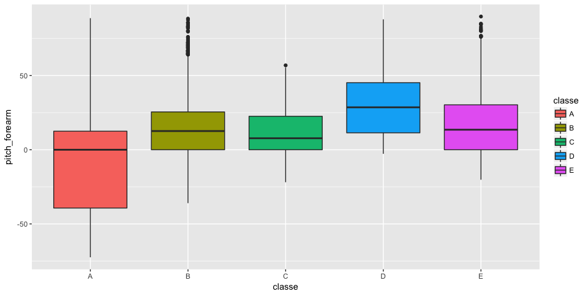

```r
bestCorPlot <- ggplot(trainingSubSet, aes(classe,pitch_forearm)) +
  geom_boxplot(aes(fill=classe))
bestCorPlot
```

It seems there is no clear linearity, with the best correlated variable.